# Multidimensional Scaling

Cara Cannella, Alexandra Elias, Alex Kremzier

November 25, 2018

## Introduction to Multidimensional Scaling

Multidimensional scaling (MDS) is a dimension reduction technique that is most useful for visualizing high-dimensional data during the exploratory phase. MDS “represents measurements of similarity (or dissimilarity) among pairs of objects as distances between points.” Simply put, objects closer together (in terms of MDS coordinates) are more similar than objects farther apart. There are two types of MDS: metric, which deals with quantitative dissimilarities, and non-metric, which deals with qualitative (ordinal) dissimilarities. Within metric MDS, classical MDS involves minimizing a loss function called Strain, which is equivalent to performing eigenvalue decomposition on the Gram matrix of the dissimilarity measure. When the dissimilarity measure is Euclidean distance, classical MDS is the same as Principal Components Analysis. However, the dissimilarity measure need not be Euclidean distance, as we demonstrate below.

## Data Description

The data used in the following example comes from the Cars93 dataset available in the R’s MASS package. The observations of the dataset are 93 randomly selected 1993 passenger car models listed in the Consumer Reports issue and PACE Buying Guide. Additional information contained in the dataset includes various automobile metrics such as price, horsepower, and luggage capacity. For raw data click [here.](http://jse.amstat.org/datasets/93cars.dat.txt?fbclid=IwAR19EJDNQzMMQOBe6ZC4t4li0zx0UpkDBAoSWDNWa3T54JXc-yfpPiPIqsk)

## Implementation

### R (smacof & data.table)

```r
# Libraries
library(MASS)
library(tidyverse)
library(ggplot2)
library(data.table)
library(smacof)
```

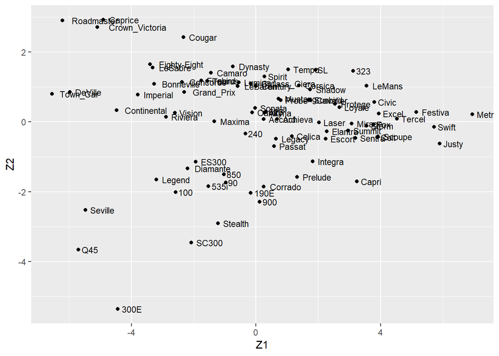

```r
# Get data
Cars93 = as.data.table(MASS::Cars93)

Cars93 = Cars93[!is.na(Rear.seat.room) & !is.na(Luggage.room)]

Cars93_cont_scaled = Cars93[,.(Min.Price, Price, Max.Price,
                               MPG.city, MPG.highway, EngineSize,
                               Horsepower, RPM, Rev.per.mile,
                               Length, Wheelbase, Width,
                               Turn.circle, Rear.seat.room,
                               Luggage.room)] %>%
                      scale()

for (method in c('euclidean', 'manhattan', 'maximum')) {
  assign(paste("distance", method, sep='_'), dist(Cars93_cont_scaled, method = method))
}

distance_correlation = sqrt(2*(1-cor(t(Cars93_cont_scaled))))

# Euclidean Distance
torgerson_euclidean = torgerson(distance_euclidean)
df_euclidean = data.frame(
  Z1=torgerson_euclidean[,1], Z2=torgerson_euclidean[,2],
  Manufacturer=Cars93$Manufacturer,
  Model=Cars93$Model,
  Type=Cars93$Type,
  DriveTrain=Cars93$DriveTrain,
  Cylinders=Cars93$Cylinders,
  Passengers=Cars93$Passengers,
  Origin=Cars93$Origin)
ggplot(df_euclidean, aes(x=Z1,y=Z2),main='Main') +
  geom_point() +
  geom_text(aes(label=Model), hjust=-0.2, size=3)
```

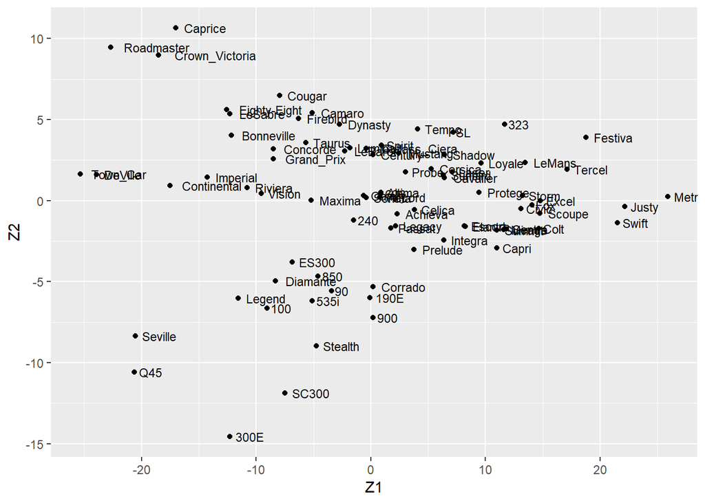

```r
# Manhattan Distance
torgerson_manhattan = torgerson(distance_manhattan)
df_manhattan = data.frame(
  Z1=torgerson_manhattan[,1], Z2=torgerson_manhattan[,2],
  Manufacturer=Cars93$Manufacturer,
  Model=Cars93$Model,
  Type=Cars93$Type,
  DriveTrain=Cars93$DriveTrain,
  Cylinders=Cars93$Cylinders,
  Passengers=Cars93$Passengers,
  Origin=Cars93$Origin)
ggplot(df_manhattan, aes(x=Z1,y=Z2),main='Main') +
  geom_point() +
  geom_text(aes(label=Model), hjust=-0.2, size=3)
```

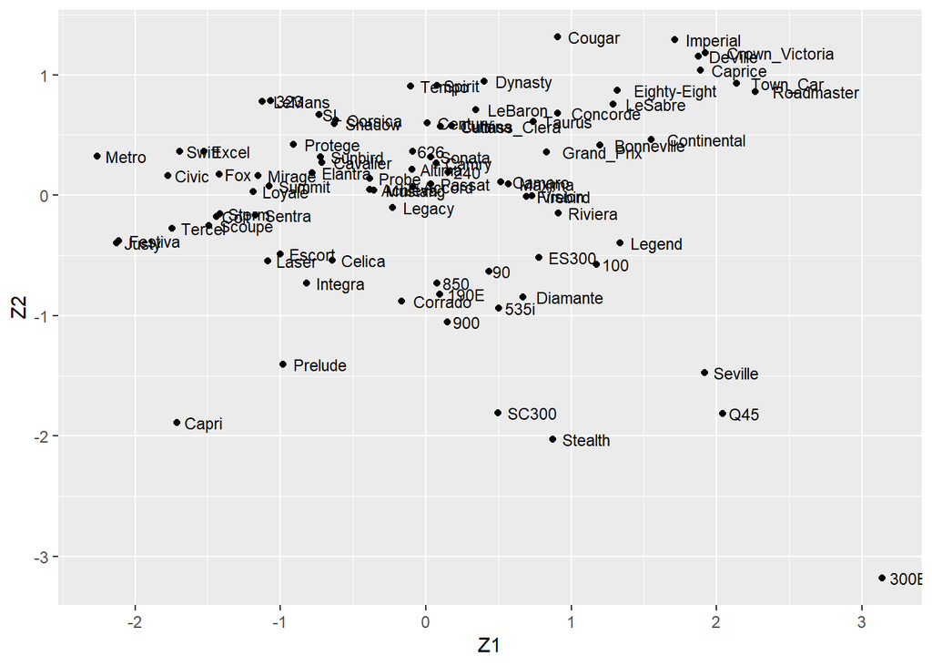

```r
# Maximum Distance
torgerson_maximum = torgerson(distance_maximum)
df_maximum = data.frame(
  Z1=torgerson_maximum[,1], Z2=torgerson_maximum[,2],
  Manufacturer=Cars93$Manufacturer,
  Model=Cars93$Model,
  Type=Cars93$Type,
  DriveTrain=Cars93$DriveTrain,
  Cylinders=Cars93$Cylinders,
  Passengers=Cars93$Passengers,
  Origin=Cars93$Origin)
ggplot(df_maximum, aes(x=Z1,y=Z2),main='Main') +
  geom_point() +
  geom_text(aes(label=Model), hjust=-0.2, size=3)
```

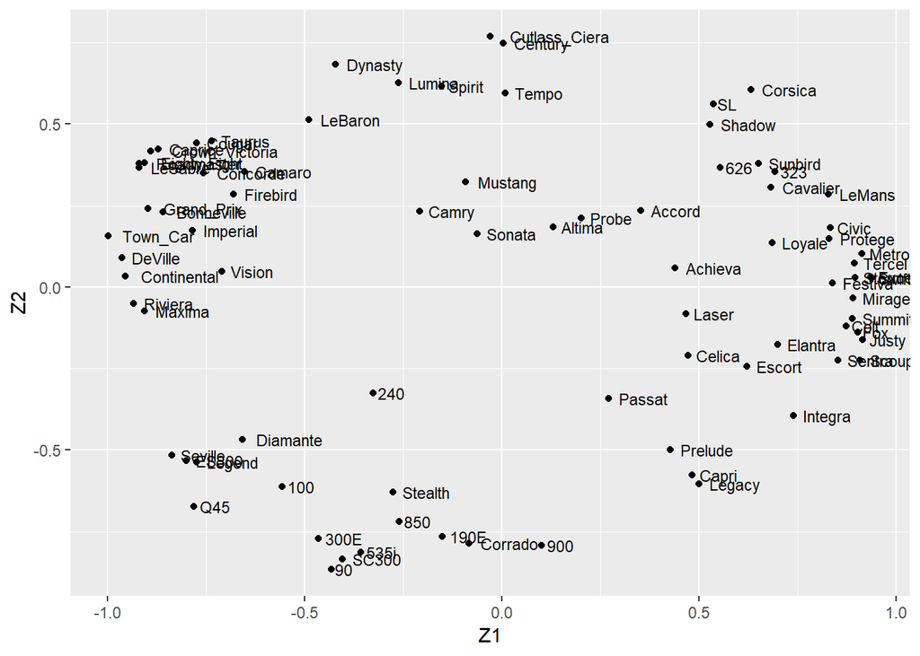

```r
# Correlation
torgerson_correlation = torgerson(distance_correlation)
df_correlation = data.frame(
  Z1=torgerson_correlation[,1], Z2=torgerson_correlation[,2],
  Manufacturer=Cars93$Manufacturer,
  Model=Cars93$Model,
  Type=Cars93$Type,
  DriveTrain=Cars93$DriveTrain,
  Cylinders=Cars93$Cylinders,
  Passengers=Cars93$Passengers,
  Origin=Cars93$Origin)
ggplot(df_correlation, aes(x=Z1,y=Z2),main='Main') +
  geom_point() +
  geom_text(aes(label=Model), hjust=-0.2, size=3)
```

### R (Base R & dplyr)

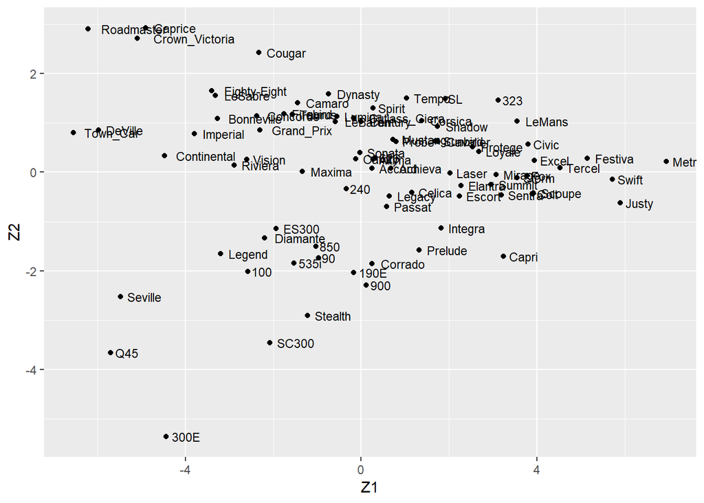

```r
# Libraries
library(MASS)
library(tidyverse)
library(dplyr)
library(ggplot2)

# Get data
cars93 =
  as_tibble(Cars93)

# Clean data
cars93 = filter(cars93,!is.na(Rear.seat.room) & !is.na(Luggage.room))

cars93_scaled =
  cars93 %>%
  select(Min.Price, Price, Max.Price,
         MPG.city, MPG.highway, EngineSize,
         Horsepower, RPM, Rev.per.mile,
         Length, Wheelbase, Width,
         Turn.circle, Rear.seat.room,
         Luggage.room) %>%
  scale() %>%
  as_tibble()

for (method in c('euclidean', 'manhattan', 'maximum')) {
  assign(paste("distance", method, sep='_'), dist(cars93_scaled, method = method))
}

distance_correlation = sqrt(2*(1-cor(t(cars93_scaled))))

# Euclidean Distance
euclidean = cmdscale(distance_euclidean, k=2)

euclidean_df = data_frame(
  Z1=euclidean[,1], Z2=euclidean[,2],
  Manufacturer=cars93$Manufacturer,
  Model=cars93$Model,
  Type=cars93$Type,
  DriveTrain=cars93$DriveTrain,
  Cylinders=cars93$Cylinders,
  Passengers=cars93$Passengers,
  Origin=cars93$Origin)

ggplot(euclidean_df, aes(x=Z1,y=Z2), main='Main') +
  geom_point() +
  geom_text(aes(label=Model), hjust=-0.2, size=3)
```

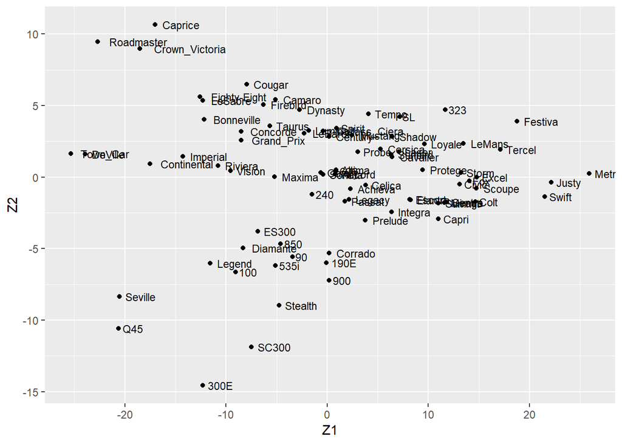

```r
# Manhattan Distance
manhattan = cmdscale(distance_manhattan, k=2)

manhattan_df = data.frame(
  Z1=manhattan[,1], Z2=manhattan[,2],
  Manufacturer=cars93$Manufacturer,
  Model=cars93$Model,
  Type=cars93$Type,
  DriveTrain=cars93$DriveTrain,
  Cylinders=cars93$Cylinders,
  Passengers=cars93$Passengers,
  Origin=cars93$Origin)

ggplot(manhattan_df, aes(x=Z1,y=Z2),main='Main') +
  geom_point() +
  geom_text(aes(label=Model), hjust=-0.2, size=3)
```

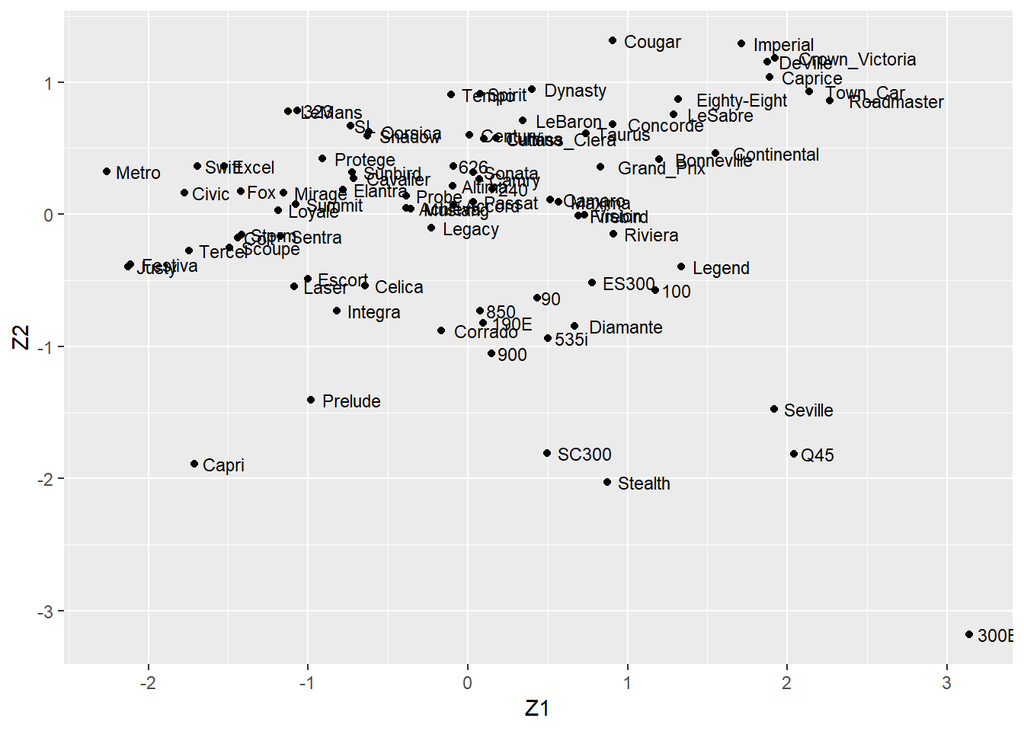

```r
# Maximum Distance
maximum = cmdscale(distance_maximum, k=2)

maximum_df = data.frame(
  Z1=maximum[,1], Z2=maximum[,2],
  Manufacturer=cars93$Manufacturer,
  Model=cars93$Model,
  Type=cars93$Type,
  DriveTrain=cars93$DriveTrain,
  Cylinders=cars93$Cylinders,
  Passengers=cars93$Passengers,
  Origin=cars93$Origin)

ggplot(maximum_df, aes(x=Z1,y=Z2),main='Main') +
  geom_point() +
  geom_text(aes(label=Model), hjust=-0.2, size=3)
```

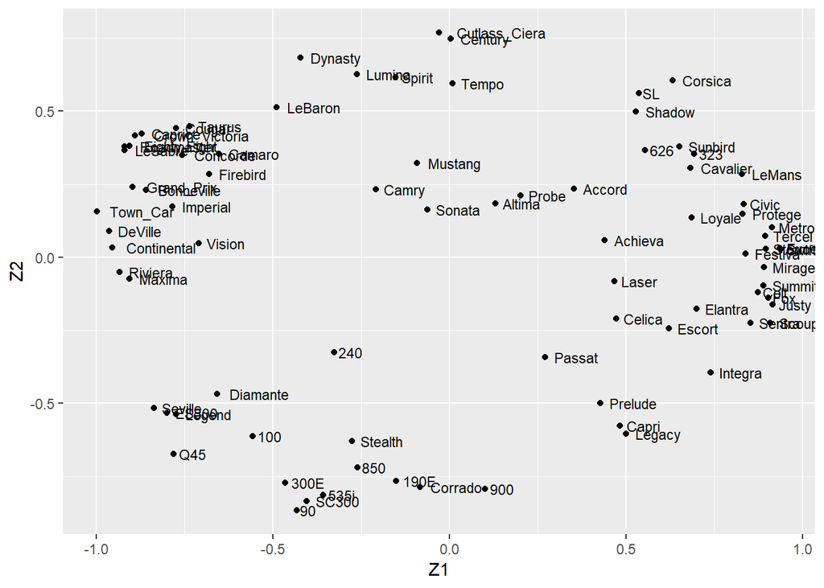

```r
# Correlation
correlation = cmdscale(distance_correlation, k=2)

correlation_df = data.frame(
  Z1=correlation[,1], Z2=correlation[,2],
  Manufacturer=cars93$Manufacturer,
  Model=cars93$Model,
  Type=cars93$Type,
  DriveTrain=cars93$DriveTrain,
  Cylinders=cars93$Cylinders,
  Passengers=cars93$Passengers,
  Origin=cars93$Origin)

ggplot(correlation_df, aes(x=Z1,y=Z2),main='Main') +
  geom_point() +
  geom_text(aes(label=Model), hjust=-0.2, size=3)
```

### Stata

```
//Import data
import delim using "Cars93.csv", varnames(1) clear

//Drop observations with missing values in rearseatroom or luggageroom
drop if rearseatroom == "NA" | luggageroom == "NA"
destring rearseatroom luggageroom, replace

//Macro of continuous variables
local varlist minprice price maxprice mpgcity mpghighway enginesize /*
    */ horsepower rpm revpermile fueltankcapacity length wheelbase width /*
    */ turncircle rearseatroom luggageroom weight
```

```
//MDS: Euclidean distances
mds `varlist', id(model) std(`varlist') noplot
mdsconfig, autoaspect ynegate msize(vsmall) mlabsize(vsmall)
```

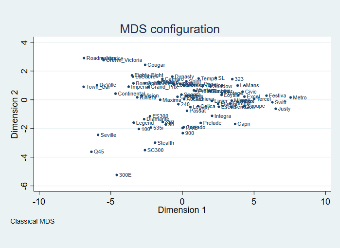

Euclidean

```
//MDS: Manhattan distances
mds `varlist', id(model) std(`varlist') measure(manhattan) noplot
mdsconfig, autoaspect ynegate msize(vsmall) mlabsize(vsmall)
```

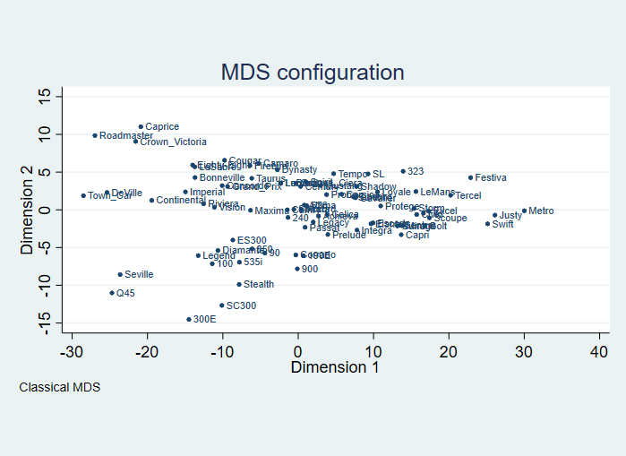

Manhattan

```
//MDS: Maximum distances
mds `varlist', id(model) std(`varlist') measure(maximum) noplot
mdsconfig, autoaspect xnegate ynegate msize(vsmall) mlabsize(vsmall)
```

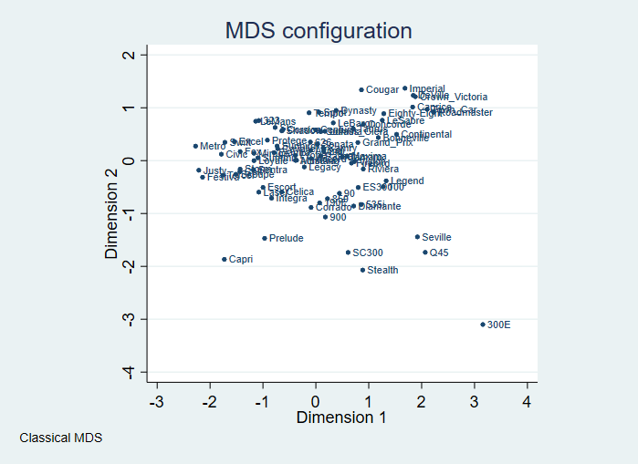

Maximum

```
//MDS: Correlation distances
mds `varlist', id(model) std(`varlist') measure(correlation) noplot
mdsconfig, autoaspect ynegate msize(vsmall) mlabsize(vsmall)
```

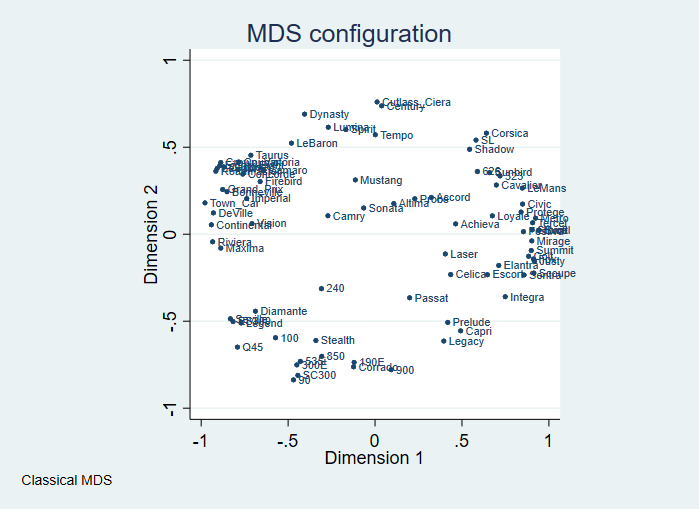

Correlation

## References

https://link.springer.com/chapter/10.1007/978-1-4757-2711-1_1

## To Do

- Collaborate with code
- Add text to examples
- Make graphs visually appealing
- Add references